# Practical Machine Learning - Fitness Device Data Analysis

mtf

Friday, August 14, 2015

In this project, we use the fitness device data from http://groupware.les.inf.puc-rio.br/har to predict if a use’s manner when he or she perform barbell lifts. There are 5 different classes (A, B, C, D, E) of manners and they are stored in the “classe” variable in the training set. We use k-fold cross-validation to estimate the out of sample error rate of our Random Forest model. Finally, we use the trained model to predict outcome for our testing data set.

### Load data

```r
training <- read.csv("pml-training.csv", na.strings = c('NA','#DIV/0!',''))
testing <- read.csv("pml-testing.csv", na.strings = c('NA','#DIV/0!',''))
```

### Preprocess data

We exclude some columns for model building purposes. The first 7 columns contain book-keeping information and we will not sure them as predictors. We will then exclude sparsed columns.

```r
training <- training[,-c(1:7)]
testing <- testing[,-c(1:7)]

non_empty_columns <- colSums(is.na(training)) == 0
testing <- testing[,non_empty_columns]
training <- training[,non_empty_columns]
```

### Explore the training data set

First, we need to look at the distribution of the outcome variable “classe” from the training set.

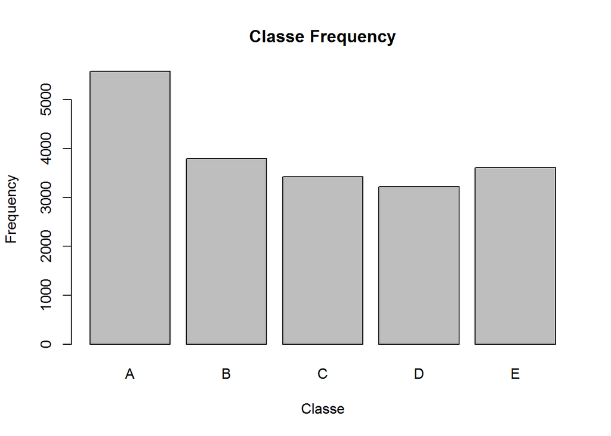

```r
barplot(table(training$classe), main='Classe Frequency', xlab = 'Classe', ylab = 'Frequency')
```

### Build our model

We are going to use 10-fold cross validation to estimate our out of sample error rate of out Random Forest model. Since we use a large K, we expect the bias of the out of sample error to be low and the variance of the out of sample error to be high. We create 10 sets of training and testing data sets. For each training and testing data set pair, we use the training data set to train the model and validate it using the testing data set. After we train the models 10 times, we find the average error rate. This error rate is our estimated out of sample error rate.

```r
library(caret)
library(doParallel);
cl <- makeCluster(detectCores())
registerDoParallel(cl)
set.seed(123)

folds <- createFolds(training$classe, 10, list = TRUE, returnTrain = TRUE)
result.error.rf <- c()
result.error.gbm <- c()

for(i in c(1:length(folds))) {
  fold_training <- training[folds[[i]], ]
  fold_testing <- training[-folds[[i]], ]

  model.rf <- train(classe ~ .
                    , data = fold_training
                    , method='rf'
                    , trControl = trainControl(method = "cv", number = 3)
                    ,  verbose=F
                    , model=FALSE)

  result.rf <- predict(model.rf, fold_testing)
  result.error.rf <- c(result.error.rf, 1- confusionMatrix(fold_testing$classe, result.rf)$overall['Accuracy'])
}
```

### Evaluate our models

```r
mean(result.error.rf)
```

```
## [1] 0.004840856
```

Our random forest model has a low estimated out of sample error rate (0.5%). So, we expect that when we use this model on the testing data set, we will have a high accuracy.

We take a final long at our model. The follow docchart shows the variable importance as measured by out Random Forrest model.

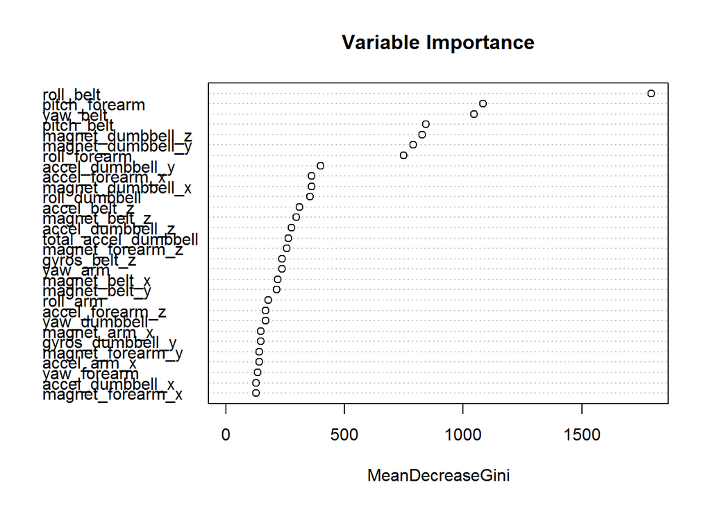

```r
varImpPlot(model.rf$finalModel
           , sort = TRUE
           , main = "Variable Importance")
```

The roll_belt variable is the most important variable of the model.

### Pridiction using the testing dataset

```r
answers  <- predict(model.rf, testing)
```

### Output results

Store prediction results into files.

```r
pml_write_files = function(x){
  n = length(x)
  for(i in 1:n){
    filename = paste0("problem_id_",i,".txt")
    write.table(x[i],file=filename,quote=FALSE,row.names=FALSE,col.names=FALSE)
  }
}

pml_write_files(answers)
```